# MayuriJoshi-L01-EngeryLoads

```python
# import pandas and numpy modules
# import matplotlib and seaborn package for plotting graphs
import numpy as np
import pandas as pd
from pandas.tools.plotting import scatter_matrix
import matplotlib.pyplot as plt
import seaborn as sns
```

```python
# Read and import energy Loads data using pandas read method
energyLoadsdf = pd.read_csv('EnergyEfficiencyData.csv')
```

Find out number of observations and number of features present in the data set using shape method

```python
energyLoadsdf.shape
```

```
(768, 10)
```

Find out data type of each column

```python
energyLoadsdf.dtypes
```

```
Relative Compactness         float64
Surface Area                 float64
Wall Area                    float64
Roof Area                    float64
Overall Height               float64
Orientation                    int64
Glazing Area                 float64
Glazing Area Distribution      int64
Heating Load                 float64
Cooling Load                 float64
dtype: object
```

Some key things to notice here are: There are 768 rows or observations in the data set. The data set has 10 variables or columns. Columns have a type of either float64 (floating point number), or int64 (integer).

```python
#Read first and last 10 records
energyLoadsdf.head(10)
```

|  | Relative Compactness | Surface Area | Wall Area | Roof Area | Overall Height | Orientation | Glazing Area | Glazing Area Distribution | Heating Load | Cooling Load |
| --- | --- | --- | --- | --- | --- | --- | --- | --- | --- | --- |
| 0 | 0.98 | 514.5 | 294.0 | 110.25 | 7.0 | 2 | 0.0 | 0 | 15.55 | 21.33 |
| 1 | 0.98 | 514.5 | 294.0 | 110.25 | 7.0 | 3 | 0.0 | 0 | 15.55 | 21.33 |
| 2 | 0.98 | 514.5 | 294.0 | 110.25 | 7.0 | 4 | 0.0 | 0 | 15.55 | 21.33 |
| 3 | 0.98 | 514.5 | 294.0 | 110.25 | 7.0 | 5 | 0.0 | 0 | 15.55 | 21.33 |
| 4 | 0.90 | 563.5 | 318.5 | 122.50 | 7.0 | 2 | 0.0 | 0 | 20.84 | 28.28 |
| 5 | 0.90 | 563.5 | 318.5 | 122.50 | 7.0 | 3 | 0.0 | 0 | 21.46 | 25.38 |
| 6 | 0.90 | 563.5 | 318.5 | 122.50 | 7.0 | 4 | 0.0 | 0 | 20.71 | 25.16 |
| 7 | 0.90 | 563.5 | 318.5 | 122.50 | 7.0 | 5 | 0.0 | 0 | 19.68 | 29.60 |
| 8 | 0.86 | 588.0 | 294.0 | 147.00 | 7.0 | 2 | 0.0 | 0 | 19.50 | 27.30 |
| 9 | 0.86 | 588.0 | 294.0 | 147.00 | 7.0 | 3 | 0.0 | 0 | 19.95 | 21.97 |

```python
energyLoadsdf.tail(10)
```

|  | Relative Compactness | Surface Area | Wall Area | Roof Area | Overall Height | Orientation | Glazing Area | Glazing Area Distribution | Heating Load | Cooling Load |
| --- | --- | --- | --- | --- | --- | --- | --- | --- | --- | --- |
| 758 | 0.66 | 759.5 | 318.5 | 220.5 | 3.5 | 4 | 0.4 | 5 | 14.92 | 17.55 |
| 759 | 0.66 | 759.5 | 318.5 | 220.5 | 3.5 | 5 | 0.4 | 5 | 15.16 | 18.06 |
| 760 | 0.64 | 784.0 | 343.0 | 220.5 | 3.5 | 2 | 0.4 | 5 | 17.69 | 20.82 |
| 761 | 0.64 | 784.0 | 343.0 | 220.5 | 3.5 | 3 | 0.4 | 5 | 18.19 | 20.21 |
| 762 | 0.64 | 784.0 | 343.0 | 220.5 | 3.5 | 4 | 0.4 | 5 | 18.16 | 20.71 |
| 763 | 0.64 | 784.0 | 343.0 | 220.5 | 3.5 | 5 | 0.4 | 5 | 17.88 | 21.40 |
| 764 | 0.62 | 808.5 | 367.5 | 220.5 | 3.5 | 2 | 0.4 | 5 | 16.54 | 16.88 |
| 765 | 0.62 | 808.5 | 367.5 | 220.5 | 3.5 | 3 | 0.4 | 5 | 16.44 | 17.11 |
| 766 | 0.62 | 808.5 | 367.5 | 220.5 | 3.5 | 4 | 0.4 | 5 | 16.48 | 16.61 |
| 767 | 0.62 | 808.5 | 367.5 | 220.5 | 3.5 | 5 | 0.4 | 5 | 16.64 | 16.03 |

Check if any NaN or missing values present in the dataset

```python
energyLoadsdf.isnull().sum()
```

```
Relative Compactness         0
Surface Area                 0
Wall Area                    0
Roof Area                    0
Overall Height               0
Orientation                  0
Glazing Area                 0
Glazing Area Distribution    0
Heating Load                 0
Cooling Load                 0
dtype: int64
```

```python
#Find out the duplicate rows in the dataframe
print(energyLoadsdf.duplicated().sum())
```

```
0
```

We can see that there are no missing values in the data set

# Learn more about a data set by looking at statistical summaries.

MEASURES OF CENTRAL TENDENCY

[output not shown]

where n is the number of elements in the sample.

## We can find out following statistical information of each Numerical column

```
Min/Max
Mean
Median
Quantiles
Interquartile Range (IQR)
Standard deviation
```

```python
# Use Summary statistical method for getting more information about data set use describe method
```

```python
energyLoadsdf.describe()
```

|  | Relative Compactness | Surface Area | Wall Area | Roof Area | Overall Height | Orientation | Glazing Area | Glazing Area Distribution | Heating Load | Cooling Load |
| --- | --- | --- | --- | --- | --- | --- | --- | --- | --- | --- |
| count | 768.000000 | 768.000000 | 768.000000 | 768.000000 | 768.00000 | 768.000000 | 768.000000 | 768.00000 | 768.000000 | 768.000000 |
| mean | 0.764167 | 671.708333 | 318.500000 | 176.604167 | 5.25000 | 3.500000 | 0.234375 | 2.81250 | 22.307201 | 24.587760 |
| std | 0.105777 | 88.086116 | 43.626481 | 45.165950 | 1.75114 | 1.118763 | 0.133221 | 1.55096 | 10.090196 | 9.513306 |
| min | 0.620000 | 514.500000 | 245.000000 | 110.250000 | 3.50000 | 2.000000 | 0.000000 | 0.00000 | 6.010000 | 10.900000 |
| 25% | 0.682500 | 606.375000 | 294.000000 | 140.875000 | 3.50000 | 2.750000 | 0.100000 | 1.75000 | 12.992500 | 15.620000 |
| 50% | 0.750000 | 673.750000 | 318.500000 | 183.750000 | 5.25000 | 3.500000 | 0.250000 | 3.00000 | 18.950000 | 22.080000 |
| 75% | 0.830000 | 741.125000 | 343.000000 | 220.500000 | 7.00000 | 4.250000 | 0.400000 | 4.00000 | 31.667500 | 33.132500 |
| max | 0.980000 | 808.500000 | 416.500000 | 220.500000 | 7.00000 | 5.000000 | 0.400000 | 5.00000 | 43.100000 | 48.030000 |

# Plot scatter matrix to see the relationship between variables

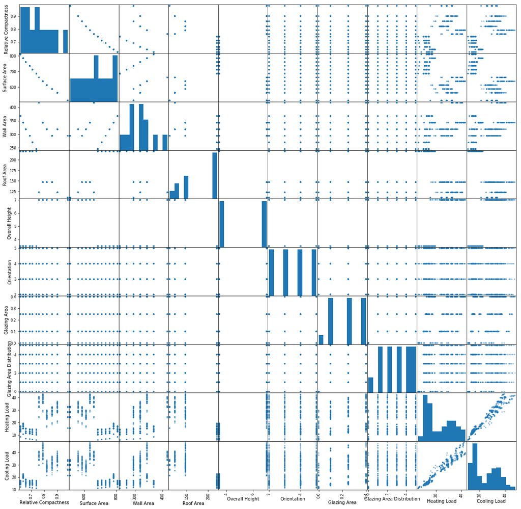

```python
# Use pandas  library to generate scatter matrix
pd.plotting.scatter_matrix(energyLoadsdf, figsize=(20,20))
plt.show()
```

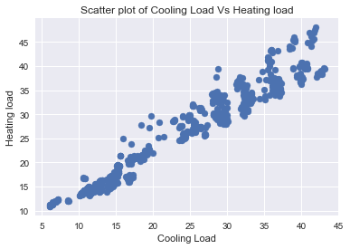

```python
#fig = plt.figure(figsize=(10, 10)) # define plot area
#import matplotlib.pyplot as plt
sns.set()
plt.xlabel("Cooling Load")
plt.ylabel("Heating load")
plt.title("Scatter plot of Cooling Load Vs Heating load")
plt.legend()
plt.scatter(energyLoadsdf['Heating Load'],energyLoadsdf['Cooling Load'])
plt.show()
```

# Observation 1

Cooling load and heating load variables are having linear relationship with each other. so we can take into account only one of them in prediction algorithm. Here I have taken only Heating load

Draw histogram of Heating load to understand the distribution

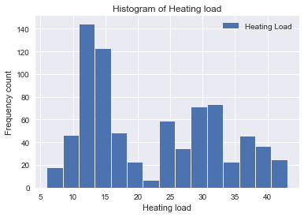

```python
%matplotlib inline
energyLoadsdf.loc[:,'Heating Load'].plot.hist(bins = 15,rwidth=0.95)
plt.xlabel("Heating load")
plt.ylabel("Frequency count")
plt.title("Histogram of Heating load")
plt.legend()
plt.show()
```

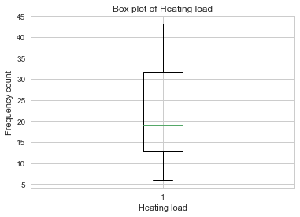

```python
import matplotlib.pyplot as plt
plt.boxplot(energyLoadsdf.loc[:,'Heating Load'])
ax.set_ylim(0, 45) # Set the limits of the y axis
plt.xlabel("Heating load")
plt.ylabel("Frequency count")
plt.title("Box plot of Heating load")
plt.legend()
plt.show()
```

```
Text(0,0.5,'Density')
```

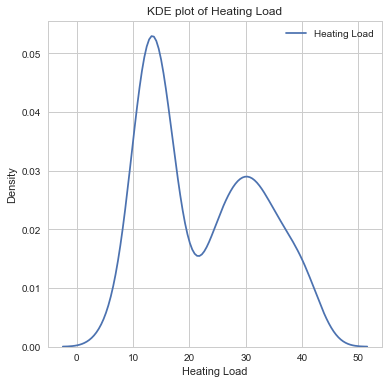

```python
import seaborn as sns
fig = plt.figure(figsize=(6,6)) # define plot area
ax = fig.gca() # define axis
sns.set_style("whitegrid")
sns.kdeplot(energyLoadsdf.loc[:, 'Heating Load'], ax = ax)
ax.set_title('KDE plot of Heating Load') # Give the plot a main title
ax.set_xlabel('Heating Load') # Set text for the x axis
ax.set_ylabel('Density')# Set text for y axis
```

# observation 2 from below scatter plot

Surface area and Relative compactness are inversly related to each other As Surface area increases Relative Compactness decresses.

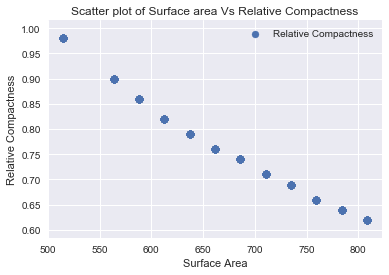

```python
import matplotlib.pyplot as plt
plt.scatter(energyLoadsdf['Surface Area'],energyLoadsdf['Relative Compactness'])
plt.xlabel("Surface Area")
plt.ylabel("Relative Compactness")
plt.title("Scatter plot of Surface area Vs Relative Compactness")
plt.legend()
plt.show()
```

```
array([<matplotlib.axes._subplots.AxesSubplot object at 0x000002549A653DD8>,
       <matplotlib.axes._subplots.AxesSubplot object at 0x000002549A57AC50>], dtype=object)
```

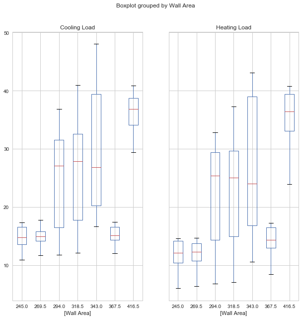

```python
import matplotlib.pyplot as plt
fig = plt.figure(figsize=(10, 10)) # define plot area
ax = fig.gca() # define axis
ax.set_title('Box plot of Heating load vs Wall area') # Give the plot a main title
ax.set_ylabel('Heating Load')# Set text for y axis
ax.set_xlabel('Wall area')# Set text for y axis
ax.set_ylim(5, 45)# Set the limits of the y axis
energyLoadsdf.loc[:,['Heating Load', 'Cooling Load','Wall Area']].boxplot(by = ['Wall Area'], ax = ax)
```

# 1 st key point

## The heating load and cooling load of buildings depends on Wall Area

### This can be seen by the box plot above

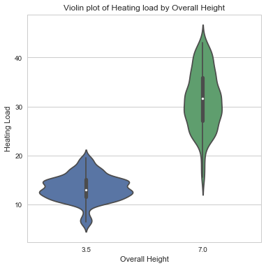

```python
import matplotlib.pyplot as plt
fig = plt.figure(figsize=(6,6)) # define plot area
ax = fig.gca() # define axis
sns.set_style("whitegrid")

ax.set_ylabel('Heating Load')# Set text for y axis
ax.set_xlabel('Overall Height')# Set text for y axis

ax.set_title('Violin plot of Heating load by Overall Height') # Give the plot a main title
ax.set_ylabel('Heating Load') # Set text for the x axis
ax.set_xlabel('Overall Height')# Set text for y axis

sns.violinplot(y = 'Heating Load', x = 'Overall Height', data = energyLoadsdf, ax = ax)
```

# 2nd key point

## The heating load of buildings depends on Overall height

### Higher the OverAll Height more Heating load.Heating load increases as Overall Height increases

### This can be seen by the Violin plot above

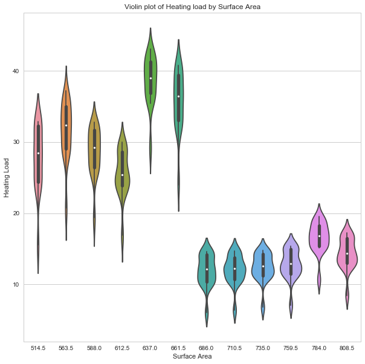

```python
import matplotlib.pyplot as plt
fig = plt.figure(figsize=(10,10)) # define plot area
ax = fig.gca() # define axis
sns.set_style("whitegrid")

ax.set_ylabel('Heating Load')# Set text for y axis
ax.set_xlabel('Surface Area')# Set text for y axis

ax.set_title('Violin plot of Heating load by Surface Area') # Give the plot a main title
ax.set_ylabel('Heating Load') # Set text for the x axis
ax.set_xlabel('Surface Area')# Set text for y axis

sns.violinplot(y = 'Heating Load', x = 'Surface Area', data = energyLoadsdf, ax = ax)


# Heating Load is inversaly related to Surface area, it decreases as the Surface area increases
## This can be seen in the voilin plot above
```

# 3rd key point

## The heating load of buildings depends on Surface Area

### This can be seen by the Violin plot above

```python
import seaborn as sns
fig  = plt.figure(figsize=(6,6)) # define plot area
ax = fig.gca() # define axis
sns.set_style("whitegrid")
sns.kdeplot(energyLoadsdf.loc[:, 'Heating Load'], ax = ax)
ax.set_title('KDE plot of Heating Load') # Give the plot a main title
ax.set_xlabel('Heating Load') # Set text for the x axis
ax.set_ylabel('Density')# Set text for y axis
```

[output not shown]

```
array([<matplotlib.axes._subplots.AxesSubplot object at 0x0000025499EC2940>,
       <matplotlib.axes._subplots.AxesSubplot object at 0x000002549A030A90>], dtype=object)
```

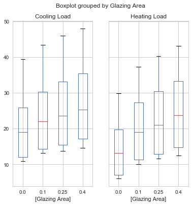

```python
import matplotlib.pyplot as plt
fig = plt.figure(figsize=(6, 6)) # define plot area
ax = fig.gca() # define axis
ax.set_title('Box plot of Heating load vs Glazing area') # Give the plot a main title
ax.set_ylabel('Heating Load')# Set text for y axis
ax.set_xlabel('Glazing Area')# Set text for y axis
ax.set_ylim(5, 45)# Set the limits of the y axis
energyLoadsdf.loc[:,['Heating Load', 'Cooling Load','Glazing Area']].boxplot(by = ['Glazing Area'], ax = ax)
```

# 4th key factor

## The heating load of buildings depends on Glazing Area

### As glazing Area increases, heating load also increases

### This can be observed by above boxplot graphs above

[figure not shown]

```python
import matplotlib.pyplot as plt
fig = plt.figure(figsize=(6,6)) # define plot area
ax = fig.gca() # define axis
sns.set_style("whitegrid")

ax.set_ylabel('Heating Load')# Set text for y axis
ax.set_xlabel('Orientation')# Set text for y axis

ax.set_title('KDE plot of Heating load by Wall area') # Give the plot a main title
ax.set_ylabel('Heating Load') # Set text for the x axis
ax.set_xlabel('Wall area')# Set text for y axis

sns.violinplot(y = 'Heating Load', x = 'Orientation', data = energyLoadsdf, ax = ax)
```

# 5th key factor

## Heating load does not depend on Orientation .

### This can be seen from above graph.

### There is no change in the heating load for any orientation value. so we can eliminate this column